# Detecting Circular Target via Non-Linear Minimization Method

Detecting circular target with log files collected from automated robots

# General Background/Research Purpose

# Brief Background Information about the datasets

In general, the raw dataset contains log files from 100 different experiments.

The target which the robot was searching for was a circular target with 0.5 m radius.

At each position, the robot recorded tiem time, robot position (x, y) and what it ‘sees’. Robot can detects/‘sees’ objects within 2 meter circle.

In each log file, it includes every location the robot went and the signal collected from nearby envirmoment.

If the robot finds the circular target/or at least think it finds the target, it will stop. If not, the robot will keep searching until experiment time run out (set to be 30 min)

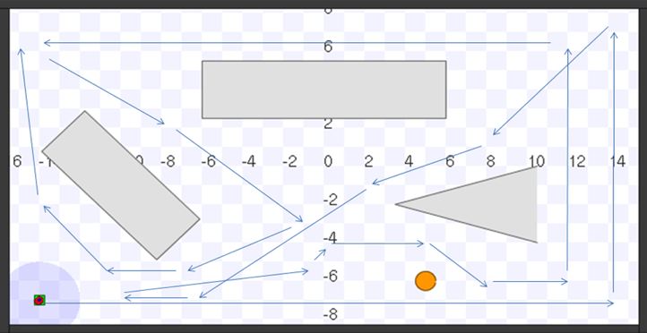

```r
setwd('~/Documents/DataScience/R/CaseStudyR/Chapter4CircularTarget/')

knitr::include_graphics("minefield.png")
```

# Data Analysis Method

I divided my study into 7 sections in total.

In the first section, I loaded all the required libraries and 100 log files and briefly looked at their sizes.

```r
### 1. Load libraries and log file size
library(dplyr)
library(profvis)
```

```r
library(ggplot2)
library(RSQLite)
library(gridExtra)
ff <- list.files(path="~/Documents/DataScience/R/CaseStudyR/Chapter4CircularTarget/", pattern = "JRSPdata.*\\.log")

# ff
# 100 log files in total

# datainfo<- file.info(ff)
# summary(datainfo$size/1024^2)

# plot(density(datainfo$size/1024^2), xlab = "megabytes--size/(1024^2)", ylab = "Density")

# quantile(info$size/1024^2, seq(.9, 1, by = .01))
```

In section 2, I defined two functions read_logfile_v2 to clean each log file and convert it into a dataframe and then use PreprocessFileCacheToSQL function to save them into SQL database. In the end, all the data was saved into logs (list with 100 elements).

```r
# testlines<-readLines('JRSPdata_2010_03_10_12_12_31.log')
# testlines[1:10]
# testlines[50:60]
# Notice: each line has different length

# take line 99 and 100 as examples
# tokens <- strsplit(testlines[99], "[[:space:]]+") # robot position
# tokens[1]
# tokens[[1]][4]
# tokens_next <- strsplit(testlines[100], "[[:space:]]+") # a look
# tokens_next[1]
# tokens_next[[1]][6]

read_Logfile_v2 <-
  function(filename = "JRSPdata_2010_03_10_12_12_31.log")
  {
    lines=readLines(filename)
    lines = grep("##", lines, invert = TRUE, value = TRUE)
    tokens = strsplit(lines, "[[:space:]]+")
    # tokens = { {line1_part1, line_part2, ...}, {line2_part1, ...], ....]

    results=NULL
    count<-1
    for (i in 1:(length(tokens)-1)){
      if (tokens[[i]][4]=="position2d" & tokens[[i]][6] == "001" & tokens[[i+1]][4]=="laser" & tokens[[i]][6] == "001") {
        results[[count]]<-c(tokens[[i]][c(1, 8, 9)], tokens[[i+1]][c(seq(14, by = 2, length = 361))])
        count=count+1
      }
    }
    TimeXYRecording<-as.data.frame(do.call('rbind',results),stringsAsFactors=FALSE)
    names(TimeXYRecording) = c("time", "x", "y", sprintf("range%d", 1:361))
    TimeXYRecording <- mutate_all(TimeXYRecording,
                                  function(x) as.numeric(as.character(x)))
    invisible(TimeXYRecording)
  }

# profvis(test<-read_Logfile_v2(filename = "JRSPdata_2010_03_10_12_12_31.log"))
# system.time(logs<-lapply(ff, read_Logfile_v2))

PreprocessFileCacheToSQL<-function(fileName){
  con <- dbConnect(SQLite(), dbname='JRSP.db')
  tableNamePart1<-strsplit(fileName, "\\.")
  tableName<-paste(tableNamePart1[[1]][1],'.table')
  if (!dbExistsTable(con, tableName)){
    resultDF = read_Logfile_v2(fileName)
    dbWriteTable(con, tableName, resultDF,overwrite = TRUE)
  }
  resultDF<-dbReadTable(con, tableName)
  dbDisconnect(con)
  resultDF
}

logs<-lapply(ff, PreprocessFileCacheToSQL)

names(logs) <- ff
```

In the next section, I visualize robot moving path and also robot last ‘look’. The figure below is the moving path of robot made with 100 log files.

Looking at 100 robot moving trace plots below, we found out that the robot always started from bottom left corner indicating with a green dot. The time it takes to find the circular target corresponds to the shift in colors from green to red. The final location where the circular target was found/the robot stopped is marked with a blue x.

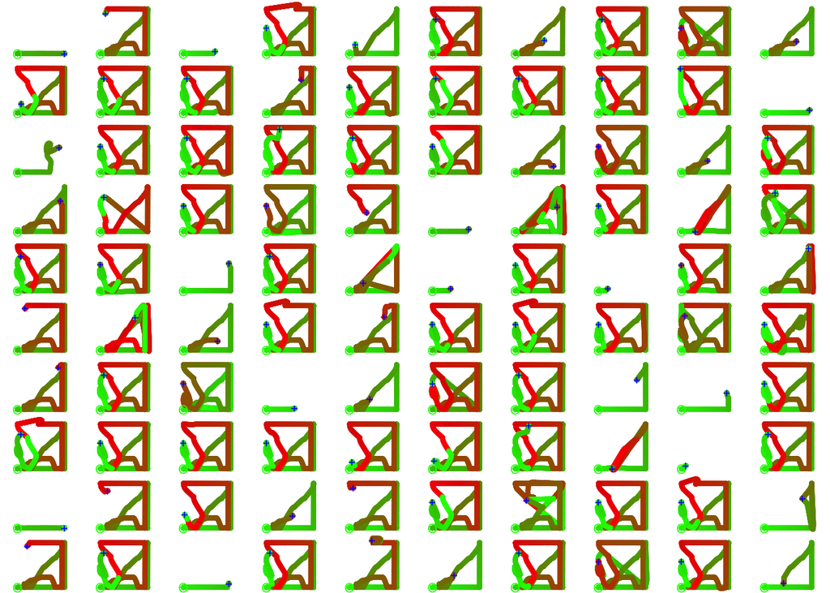

```r
makeColorRamp =
  function(n)
  {
    s = (1:n)/n
    zero = rep(0, n)
    rgb(s, (1-s), zero)
  }
# RGB: This function creates colors corresponding to the given intensities (between 0 and max) of the red, green and blue primaries.

plot.RobotLog_time =
  function(x, y, col = makeColorRamp(1800), ...)
  {
    plot(y~x, x,type="p",pch=20,col=col,...)
    points(x$x[c(1, nrow(x))], x$y[c(1, nrow(x))], pch = c("O", "+"),
           col = c("green", "blue"))
  }

par(mfrow = c(10, 10), mar = rep(0, 4), pty = 's')

invisible(lapply(logs, plot.RobotLog_time,
                 xlim = c(-16, 16), ylim = c(-8, 8),
                 axes = FALSE))
```

```r
# invisible: Return a (temporarily) invisible copy of an object.

# dev.copy(png,'RobotMovingPath.png')
# dev.off()
```

We defined CombineAllLastLook function to aggregate the last look from 100 log files into a single dataframe called ‘LastLook’. We randomly draw 9 out of 100 look from the LastLook and plotted them below. The red circle is the 2 meter range which the robot can detect. And the black line describe what the robot acutally saw from the signal collected. Just looking at these 9 plots, we saw that around 50% of the time the robot did not find the circular target at the end of the measurement.

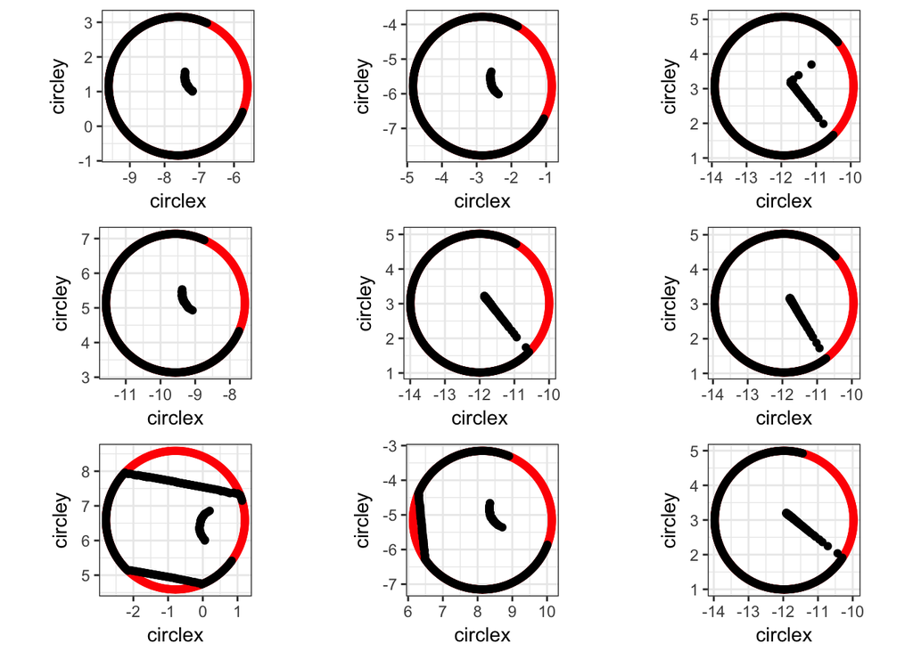

```r
CombineAllLastLook<-function(logs){
  # this will return a dataframe with last look from 100 logfiles
  lastlook_List<-NULL
  i=1
  for (logfiles in logs){
    lastlook_List[[i]]<-logfiles[nrow(logfiles), ]
    i=i+1
  }
  lastlook_df<-as.data.frame(do.call('rbind',lastlook_List),stringsAsFactors=FALSE)
  names(lastlook_df) = c("time", "x", "y", sprintf("range%d", 1:361))
  lastlook_df
}

LastLook<-CombineAllLastLook(logs)
# save all the last look in each log file into a seperate dataframe

plotLastLook_ggplot <- function(look1, ...)
{
  x=look1$x
  y=look1$y
  theta = seq(0, 2*pi, length = 360) - pi/2
  look1Signal<-as.numeric(look1[-c(1:3, 364)])
  circlex=x+2*cos(theta)
  circley=y+2*sin(theta)
  x1 = x + look1Signal*cos(theta)
  y1 = y + look1Signal*sin(theta)
  look1_df<-as.data.frame(cbind(circlex, circley, x1, y1))
  circleplot=ggplot(data=look1_df) + theme_bw() +
    geom_point(aes(x=circlex, y= circley), color='red') + geom_point(aes(x=x1, y=y1), color='black') + coord_fixed(ratio=1)
  return(circleplot)
}

LastLook87<-plotLastLook_ggplot(LastLook[87, ])
LastLook100<-plotLastLook_ggplot(LastLook[100, ])
LastLook94<-plotLastLook_ggplot(LastLook[94, ])
LastLook51<-plotLastLook_ggplot(LastLook[51, ])
LastLook92<-plotLastLook_ggplot(LastLook[92, ])
LastLook13<-plotLastLook_ggplot(LastLook[13, ])
LastLook95<-plotLastLook_ggplot(LastLook[95, ])
LastLook27<-plotLastLook_ggplot(LastLook[27, ])
LastLook44<-plotLastLook_ggplot(LastLook[44, ])

LastLookPlot<-grid.arrange(LastLook87, LastLook100, LastLook94, LastLook51,
         LastLook92, LastLook13, LastLook95,LastLook27, LastLook44, ncol=3)
```

```r
# ggsave('LastLookPlot.png',LastLookPlot, width = 9, height = 9)
```

Since robot can only ‘see’ things with 2 meter circle range, in the following section, we want to find out segments where robot ‘see’ something which might be interesting and then judge if it is the circular target we are interested. We defined three main functions (getSegments, getWrappedSegments_YG, seperateSegments_YG) to do this.

```r
### 5. Identifying segments

getSegments=
  function(range, threshold = 2){
    # range: a list with 360 in length
    rl = rle(range < threshold)

    cursor = 1
    ans = list()

    for(i in seq(along = rl$lengths)) {
      if(!rl$values[i]) {
        cursor = cursor + rl$lengths[i]
        next
      }
      ans[[length(ans) + 1]] = seq(cursor, length = rl$lengths[i])
      cursor = cursor + rl$lengths[i]
    }
    ans}

# testing section for getSegments function
# x = rep(2, 360)
# x[1:10] = seq(1.7, 1.9, 10)
# x[81:105] = seq(1.4, 1.6, 25)
# x[351:360] = seq(.3, .5, 10)
# getSegments(x)
# Problem: need to connect the first and last segments

getWrappedSegments_YG =
  function(range, threshold = 2){
    # the same input as getSegments
    segments = getSegments(range, threshold)
    if(length(segments) >= 2) {
      s_first = segments[[1]]
      s_last = segments[[length(segments)]]
      if(s_first[1] == 1 && s_last[length(s_last)] == 360) {
        segments[[1]] = c(s_last, s_first)
        segments = segments[-length(segments)]
      }
    }
    segments}

# getWrappedSegments_test<-getWrappedSegments_YG(x, threshold = 2)
# getWrappedSegments_test

# LastLook5<-plotLastLook_ggplot(LastLook[5, ])
# LastLook5

seperateSegments_YG<-function(idx, x, y, threshold=0.15){
  # seperate segments if the distance between the two points exceeds 0.15 threshold
  xdiff<-diff(x[idx])
  ydiff<-diff(y[idx])
  distance<-sqrt((xdiff)^2+(ydiff)^2)
  if (any(distance>threshold)){
    i = which(distance > threshold)[1]
    list(idx[1:(i-1)],idx[(i+1):length(idx)])
  }
  else {list(idx)}
}
```

After taking out potential segments, we need to develop a method which can judge if this segment correspond to a 0.5 meter circular target. Function circle.fit takes three inputs: p (a list which contains initial guess of the radius, x and y position of the circular target), x (a list which contains x axis information from what the robot ‘sees’), y (a list which contains y axis information from what the robot ‘sees’). It summarise the sum of squares between the two radii.

```r
### 6. Does one perticular segment correspond to a circular target?

circle.fit<-
  function(p, x, y)
  {
    # p: a list containing three elements
    # x,y: two seperate lists containing x, y position info
    x0 <- p[1] # initial guess x
    y0 <- p[2] # initial guess y
    r <- p[3] # radius of target
    actual.r <- sqrt((x - x0)^2 + (y - y0)^2)
    sum((r - actual.r)^2)
  }
```

In section 7, I define function robotEva_YG() to process each row in LastLook. This function loops over 100 last look from logfiles, extracts the segments and use circle.fit() and nlm() function to determine which segment apprears to be part of the target circle. For each segment, we also evaluate three additional criteria that actually determine whether the segment seems to be the circular target we were expected.

Firstly, the length of the segment should be greater than 3 (current default). If there is too little points present in one segment, it is not accurate to judge if it is the circular target or some other obstacles. Secondly, as everything else in real world, the radii of the circular target we were searching for is not 0.5 meter in sharp. We set a range (0.475 to 0.7 meters) to this. If it is outside of the range, we assume it is something else. Lastly, we use the final value of the sum of squares function that we are trying to minimize to measure the goodness of fit. We compare the goodness of fit to the threshold with (result$minimum/length(segment))>error threshold (0.01)

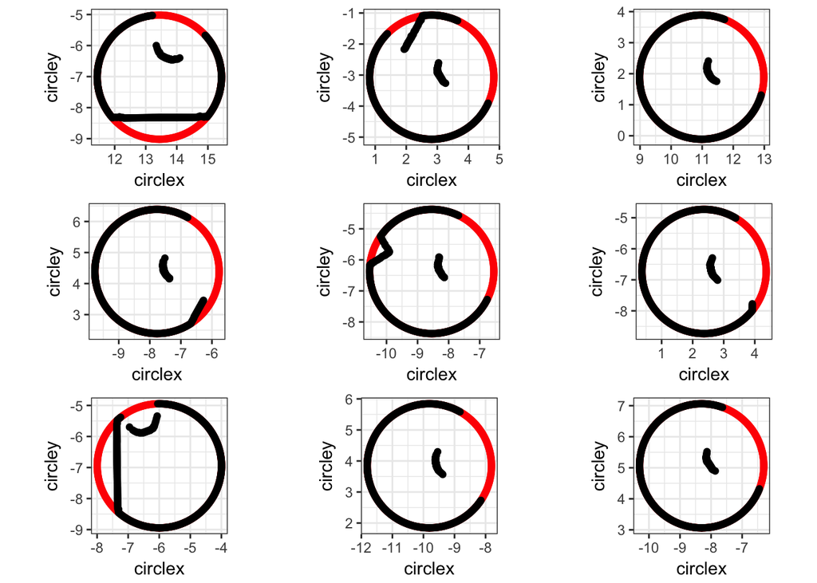

```r
### 7. Testing the classifier built for detecting circle with the LastLook dataframe

robotEva_YG<-function(LastLook, min.length = 3, max.ss.ratio = 0.01,
                      min.radius = .5, max.radius = 2, threshold = 2){
  conclusion<-NULL
  currentLine<-NULL
  theta = seq(0, 2*pi, length = 360)
  for (i in 1:nrow(LastLook)){
    currentLine<-LastLook[i,]
    x0<-currentLine$x
    y0<-currentLine$y
    range<-as.numeric(currentLine[-c(1:3, 364)])

    pos_x = x0 + cos(theta)*range
    pos_y = y0 + sin(theta)*range

    segs<-getWrappedSegments_YG(range, threshold = 2)

    for (seg in segs){
      newsegs<-seperateSegments_YG(seg,pos_x, pos_x,threshold=0.15)
      for (s in newsegs){
        if ((length(s))<min.length)
          next
        xi<-pos_x[s]
        yi<-pos_y[s]
        # temp_result<-NA
        temp_result=nlm(circle.fit, c(mean(xi), mean(yi), 0.5), x=xi, y=yi)
        if ( (temp_result$code)>3 || (temp_result$minimum/length(s))>max.ss.ratio || (temp_result$estimate[3]) < min.radius || (temp_result$estimate[3]) > max.radius)
          next
        conclusion[[i]]<- temp_result
      }
    }
  }
  conclusion
}

CircleDetection<-robotEva_YG(LastLook, min.length = 3, max.ss.ratio = 0.01,
                        min.radius = .475, max.radius = .7, threshold = 2)

# NoCircle<-sapply(CircleDetection, function(o) is.null(o))

# which(NoCircle)
# length(which(NoCircle))
# 63 out of 100 do not see the circle target in the last

# CircleErrorXYR<-sapply(CircleDetection, function(o) c(o$minimum,  o$estimate[1], o$estimate[2], o$estimate[3]))
# CircleErrorXYR<-as.data.frame(do.call(rbind, CircleErrorXYR))
# colnames(CircleErrorXYR)<-c('error', 'estimate_x', 'estimate_y', 'r')

# range(CircleErrorXYR$estimate_x)
# range(CircleErrorXYR$estimate_y)

hasCircleTF<-sapply(CircleDetection, function(o) !is.null(o))
# hasCircleTF
LastLook$hasCircle<-hasCircleTF
LastLookwithCircle<-subset(LastLook, LastLook$hasCircle=='TRUE')
LastLookwithCircle$hasCircle<-NULL
# create a seperate df which only store the ones see circle target in the end of the detection

Circle1<-plotLastLook_ggplot(LastLookwithCircle[1, ])
Circle5<-plotLastLook_ggplot(LastLookwithCircle[5, ])
Circle9<-plotLastLook_ggplot(LastLookwithCircle[9, ])
Circle13<-plotLastLook_ggplot(LastLookwithCircle[13, ])
Circle17<-plotLastLook_ggplot(LastLookwithCircle[17, ])
Circle21<-plotLastLook_ggplot(LastLookwithCircle[21, ])
Circle25<-plotLastLook_ggplot(LastLookwithCircle[25, ])
Circle29<-plotLastLook_ggplot(LastLookwithCircle[29, ])
Circle33<-plotLastLook_ggplot(LastLookwithCircle[33, ])
plotswithCircle<-grid.arrange(Circle1, Circle5, Circle9, Circle13, Circle17,
                              Circle21, Circle25, Circle29, Circle33, ncol=3)
```

```r
ggsave('plotswithCircle.png',plotswithCircle, width = 9, height = 9)
```

# Conclusions

In this study, I looked at 100 log files created by robot with the aim of finding a circular target in the end. I did some exploratory data analysis with 100 log files to study how the data was organized and how the robot was moving and under what speed. I used the data to develop a statistical classifier for idnetifying target with non linear minimization and gained an understanding of how well it works. This method could be used in real-time which the robot is moving through the course to detect circular target. It could also be useful to develop robot search strategies that combine information from series of detections and tell the robot where to go next.

# References

This example is taken from: Chapter 4 Processing Robot and Sensor Log Files: Seeking a Circular Target from the book: Case Studies in Data Science with R by Deborah Nolan, University of California, Berkeley and Duncan Temple Lang, University of California, Davis.

The complete log files can be downloaded from: http://rdatasciencecases.org/Data.html

A typical robot moving trace and experiment enviroment was shown in this figure: http://rdatasciencecases.org/Data/minefield.png